# First Analysis

Angela Carraro, Giullia Monteiro Milano Oliveira, Gaia Saveri

3/07/2020

```r
library(readr)
library(rstan)
library(dplyr)
library(ggplot2)
library(bayesplot)
library(lubridate)
```

## Load Data

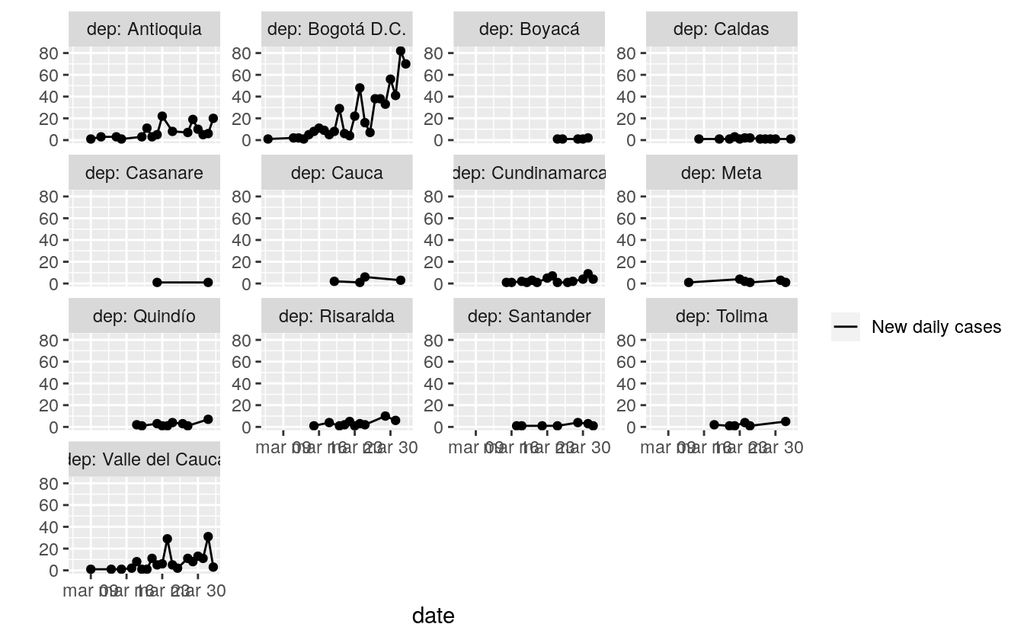

```r
df<-read_csv("data/central_colombia.csv")
ggplot(df, aes(x = date, y = n)) +
  geom_line(aes(linetype = "New daily cases")) +
  geom_point(color = "black") +
  facet_wrap(~dep, scales = "free_y", ncol = 4, labeller = label_both) +
  scale_y_continuous(name = "", limits = range(df$n)) +
  scale_linetype_discrete(name = "")
```

Please ignore tha fact that the picture is horrible, I’m starting convincing myself that we should include only the departments that have a “significant” number of cases.. maybe more than 30 cases is enough.

```r
data<-read_csv("data/central_colombia_relevant.csv")
data<-data[order(data$dep),]
data<-data[,c(1,5,2,3,4)]
head(data)
```

```
## # A tibble: 6 x 5
##   date       elapsed_time dep           n cumulative_dep
##   <date>            <dbl> <chr>     <dbl>          <dbl>
## 1 2020-03-09            3 Antioquia     1              1
## 2 2020-03-11            5 Antioquia     3              4
## 3 2020-03-14            8 Antioquia     3              7
## 4 2020-03-15            9 Antioquia     1              8
## 5 2020-03-19           13 Antioquia     3             11
## 6 2020-03-20           14 Antioquia    11             22
```

## Poisson regression

As a first attempt, we can try to fit a simple Poisson regression:

$$ln\lambda_i = \alpha + \beta\cdot elapsed\_time_i \\
y_i \sim \mathcal{Poisson}(\lambda_i)$$

with $i = 1,\dots,83$, and $y_i$ represents the number of cases.

Let’s compile the model:

```r
model.Poisson<-stan_model("stan/poisson_regression.stan")
```

Fix things to be able to run the stan model and fit the model:

```r
#arrange things
model.data<-list(
  N = nrow(data),
  cases = data$n,
  time = data$elapsed_time
)
#str(model.Poisson.data)

#run the model
fit.model.Poisson<-sampling(model.Poisson, data=model.data)
#inferred parameters
print(fit.model.Poisson, pars=c("alpha", "beta"))
```

```
## Inference for Stan model: poisson_regression.
## 4 chains, each with iter=2000; warmup=1000; thin=1;
## post-warmup draws per chain=1000, total post-warmup draws=4000.
##
##       mean se_mean   sd  2.5%  25%  50%  75% 97.5% n_eff Rhat
## alpha 0.17       0 0.13 -0.08 0.08 0.17 0.26  0.44   825 1.01
## beta  0.12       0 0.01  0.11 0.11 0.12 0.12  0.13   826 1.01
##
## Samples were drawn using NUTS(diag_e) at Mon Jun 29 17:20:54 2020.
## For each parameter, n_eff is a crude measure of effective sample size,
## and Rhat is the potential scale reduction factor on split chains (at
## convergence, Rhat=1).
```

Looking at `Rhat` we can see that we have reached the convergence.

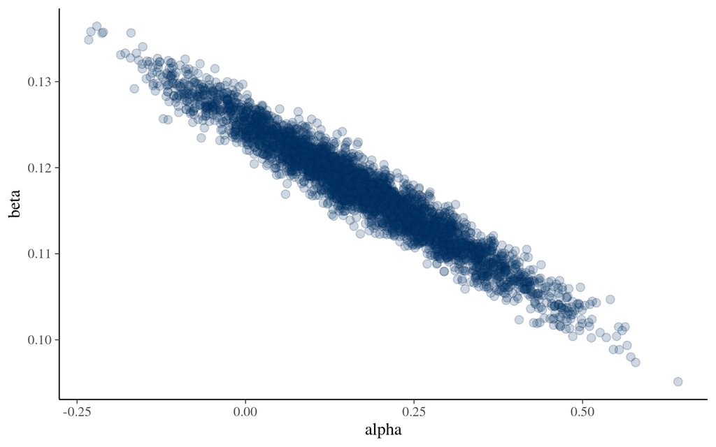

```r
theme_set(bayesplot::theme_default())

mcmc_scatter(as.matrix(fit.model.Poisson, pars=c("alpha", "beta") ), alpha=0.2)
```

Check the posterior:

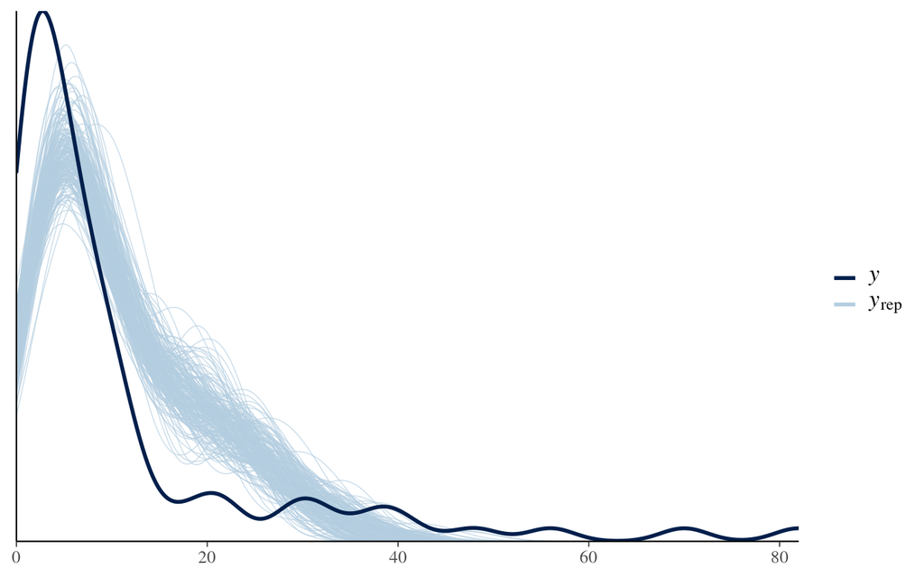

```r
y_rep<-as.matrix(fit.model.Poisson, pars="y_rep")
ppc_dens_overlay(y = model.data$cases, y_rep[1:200,])
```

The model is not able to capture low and high numbers of new cases.

The fit is not satisfactory, it is probably due to overdispersion, we can check the residuals to confirm this hypothesis:

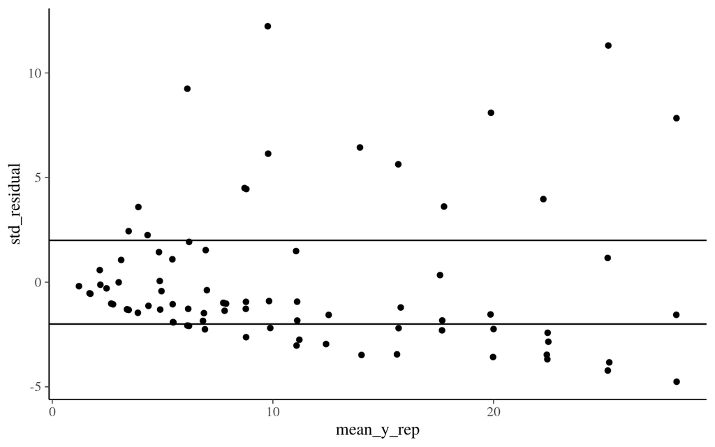

```r
#in this way we check the standardized residuals
mean_y_rep<-colMeans(y_rep)
std_residual<-(model.data$cases - mean_y_rep) / sqrt(mean_y_rep)
qplot(mean_y_rep, std_residual) + hline_at(2) + hline_at(-2)
```

The variance of the residuals increases as the predicted value increase. The standardized residuals should have mean 0 and standard deviation 1 (hence the lines at +2 and -2 indicates approximate 95% error bounds). The variance of the standardized residuals is much greater than 1, indicating a large amount of overdispersion.

Classically the problem of having overdispersed data is solved using the negative binomial model instead of the Poisson one. To be continued!

## Negative binomial model

In order to deal with the problem of overdispersed data, we can try to fit the following Negative Binomial model:

$$ln\lambda_i = \alpha + \beta\cdot elapsed\_time_i \\
y_i \sim \mathcal{Negative Binomial}(\lambda_i, \phi)$$

Where the parameter $\phi$ is called *precision* and it is such that:

$$E[y_i] = \lambda \\ Var[y_i] = \lambda + \frac{\lambda^2}{\phi}$$

again $i=1,\dots,83$. As $\phi \rightarrow \infty$ the negative binomial approaches the Poisson distribution.

Let’s compile and run the stan model:

```r
#compile
model.NB<-stan_model("stan/negative_binomial.stan")
#fit
fit.model.NB<-sampling(model.NB, data=model.data)
#inferred parameters
print(fit.model.NB, pars=c("alpha", "beta"))
```

```
## Inference for Stan model: negative_binomial.
## 4 chains, each with iter=2000; warmup=1000; thin=1;
## post-warmup draws per chain=1000, total post-warmup draws=4000.
##
##       mean se_mean   sd  2.5%   25%  50%  75% 97.5% n_eff Rhat
## alpha 0.08    0.01 0.31 -0.53 -0.12 0.08 0.29  0.72  1686    1
## beta  0.12    0.00 0.02  0.09  0.11 0.12 0.13  0.16  1530    1
##
## Samples were drawn using NUTS(diag_e) at Mon Jun 29 17:22:38 2020.
## For each parameter, n_eff is a crude measure of effective sample size,
## and Rhat is the potential scale reduction factor on split chains (at
## convergence, Rhat=1).
```

Chains have reached convergence, let’s check the fit:

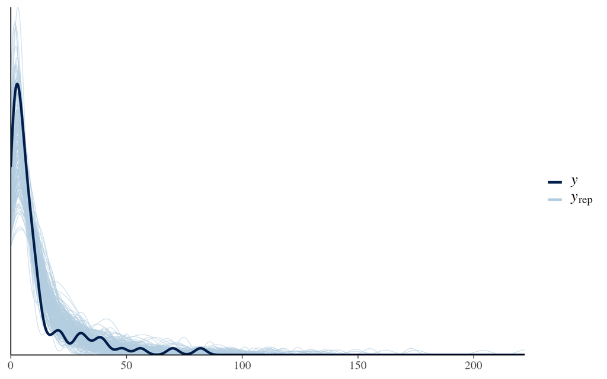

```r
#posterior predictive chiecking
samples_NB<-rstan::extract(fit.model.NB)
y_rep<-samples_NB$y_rep
ppc_dens_overlay(y = model.data$cases, y_rep[1:200,])
```

The fit seems better now! Both the tails and the peak are well captured by the model now.

Let’s look again at the standardized residuals:

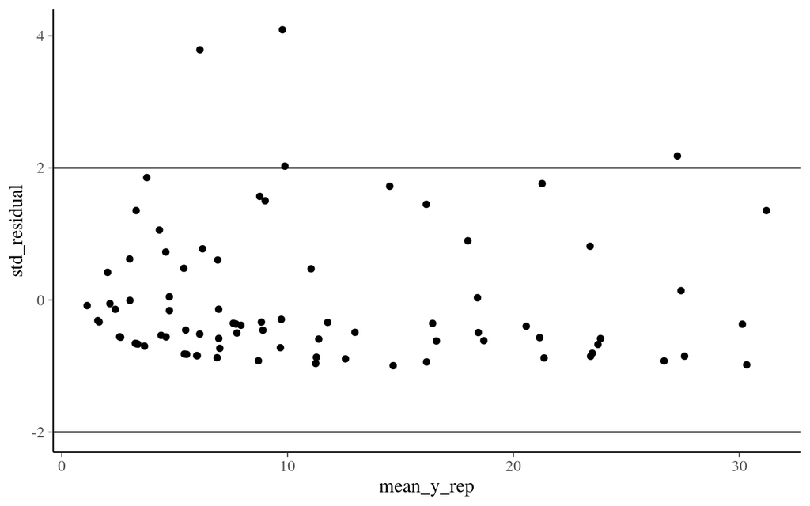

```r
mean_inv_phi<-mean(samples_NB$inv_phi)
mean_y_rep<-colMeans(y_rep)
std_residual<-(model.data$cases - mean_y_rep) / sqrt(mean_y_rep + mean_y_rep^2*mean_inv_phi)
qplot(mean_y_rep, std_residual) + hline_at(2) + hline_at(-2)
```

The situation has improved a lot, we still have a few large standardized residual.

Maybe because the situation across regions is very different, let’s check!

```r
ppc_stat_grouped(
  y = model.data$cases,
  yrep = y_rep,
  group = data$dep,
  stat = "mean",
  binwidth = 0.2
)
```

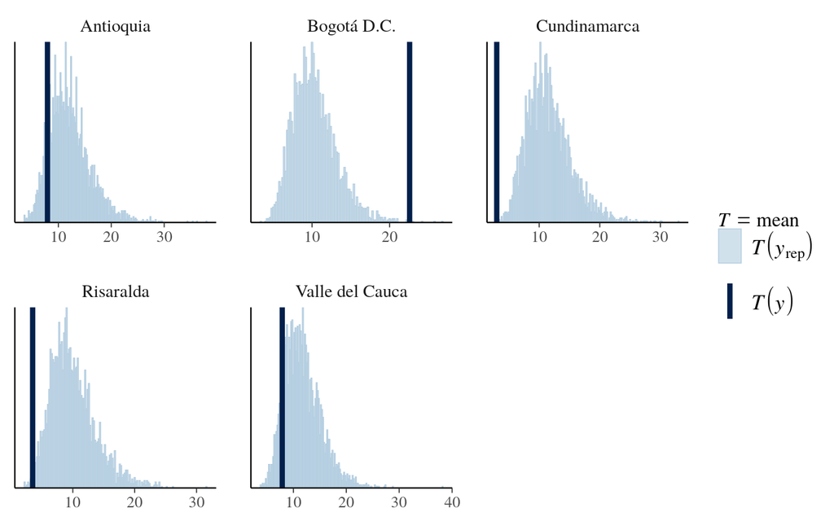

Maybe we should take into account the difference across departments, since most prediction are not accurate!

## Hierarchical modeling

We include an intercept term which should take into account the difference among regions.

So the model (varying intercept model) that we take into account is now:

$$ln\lambda_{i,d} = \alpha_d + \beta\cdot elapsed\_time_i \\
\alpha_d \sim \mathcal{N}(\mu, \sigma)\\
y_i \sim \mathcal{Negative Binomial}(\lambda_{i,d}, \phi)$$

where $d$ stands for department.

```r
data<- data %>%
  mutate(dep_idx = factor(dep, levels = unique(dep)),
          dep_id = as.integer(dep_idx)) %>%
  select(-dep_idx)
data<-data[,c(1,2,3,6,4,5)]
data
```

```
## # A tibble: 83 x 6
##    date       elapsed_time dep       dep_id     n cumulative_dep
##    <date>            <dbl> <chr>      <int> <dbl>          <dbl>
##  1 2020-03-09            3 Antioquia      1     1              1
##  2 2020-03-11            5 Antioquia      1     3              4
##  3 2020-03-14            8 Antioquia      1     3              7
##  4 2020-03-15            9 Antioquia      1     1              8
##  5 2020-03-19           13 Antioquia      1     3             11
##  6 2020-03-20           14 Antioquia      1    11             22
##  7 2020-03-21           15 Antioquia      1     3             25
##  8 2020-03-22           16 Antioquia      1     5             30
##  9 2020-03-23           17 Antioquia      1    22             52
## 10 2020-03-25           19 Antioquia      1     8             60
## # … with 73 more rows
```

```r
length(unique(data$dep_id))
```

```
## [1] 5
```

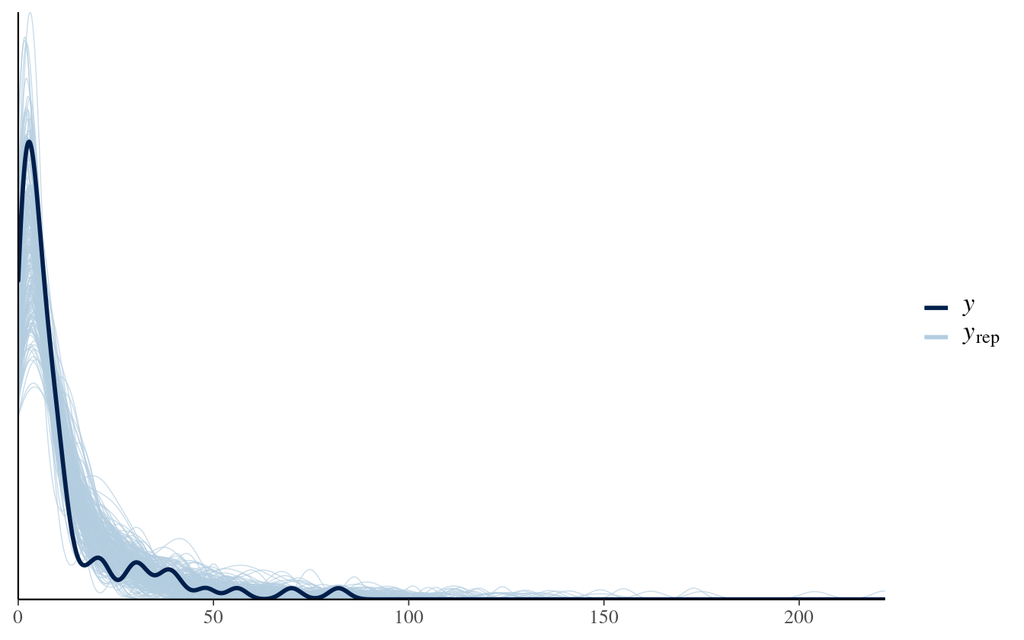

```r
#compile
model2.NB<-stan_model("stan/NB_model2.stan")

#modify model data to add necessary things
model2.data<-with(data,
                  list(D=length(unique(data$dep_id)),
                       N=nrow(data),
                       cases = n,
                       dep = data$dep_id,
                       time = data$elapsed_time
                       )
)
#fit
fit.model2.NB<-sampling(model2.NB, model2.data)
#save sampling
samples_NB2<-rstan::extract(fit.model.NB)
y_rep<-samples_NB2$y_rep
ppc_dens_overlay(y = model2.data$cases, y_rep[1:200,])
```

Let’s check if there is difference in the accuracy across departments with respect to the previous model:

```r
ppc_stat_grouped(
  y = model2.data$cases,
  yrep = y_rep,
  group = data$dep,
  stat = "mean",
  binwidth = 0.5
)
```

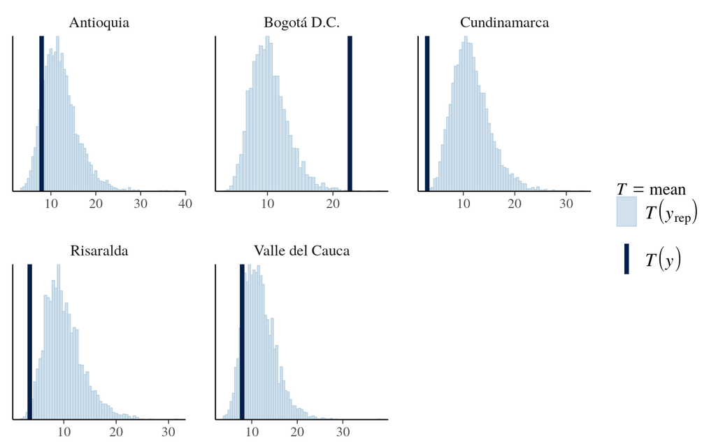

Unfortunately the situation has not changed under this point of view :(

Let’s check the residuals:

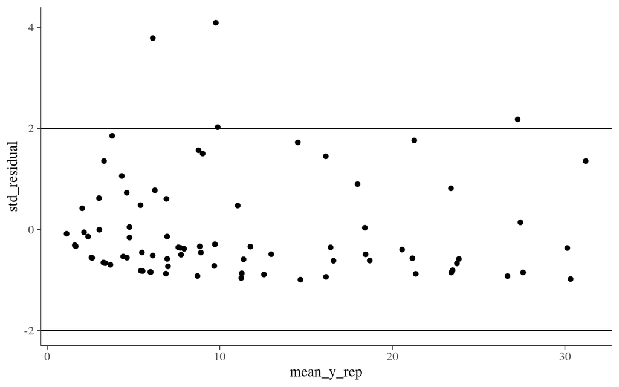

```r
mean_inv_phi<-mean(samples_NB2$inv_phi)
mean_y_rep<-colMeans(y_rep)
std_residual<-(model.data$cases - mean_y_rep) / sqrt(mean_y_rep + mean_y_rep^2*mean_inv_phi)
qplot(mean_y_rep, std_residual) + hline_at(2) + hline_at(-2)
```

very few points are outside the 95% confidence interval now!

## Reference

At the moment -i’m using as a reference the book `Hierarchical_Models.pdf` in the folder `books`.. and a lot of Google!